# Bayesian data analysis demo 5.1

Aki Vehtari, Markus Paasiniemi

2022-10-26

## Hierarchical model for Rats experiment (BDA3, p. 102)

ggplot2, grid, and gridExtra are used for plotting, tidyr for manipulating data frames

```r
library(ggplot2)
theme_set(theme_minimal())
library(gridExtra)
library(tidyr)
library(latex2exp)
```

Data

```r
y <- c(0,0,0,0,0,0,0,0,0,0,0,0,0,0,1,1,1,1,1,1,1,1,2,2,2,2,2,2,2,2,
        2,1,5,2,5,3,2,7,7,3,3,2,9,10,4,4,4,4,4,4,4,10,4,4,4,5,11,12,
        5,5,6,5,6,6,6,6,16,15,15,9,4)
n <- c(20,20,20,20,20,20,20,19,19,19,19,18,18,17,20,20,20,20,19,19,18,18,25,24,
       23,20,20,20,20,20,20,10,49,19,46,27,17,49,47,20,20,13,48,50,20,20,20,20,
       20,20,20,48,19,19,19,22,46,49,20,20,23,19,22,20,20,20,52,46,47,24,14)
```

Evaluate densities in grid

```r
x <- seq(0.0001, 0.9999, length.out = 1000)
```

Helper function to evaluate density over observations

```r
bdens <- function(n, y, x)
    dbeta(x, y+1, n-y+1)
```

Separate model

```r
df_sep <- mapply(bdens, n, y, MoreArgs = list(x = x)) %>%
  as.data.frame() %>% cbind(x) %>%
  pivot_longer(cols = !x, names_to = "ind", values_to = "p")
```

Plot the separate model

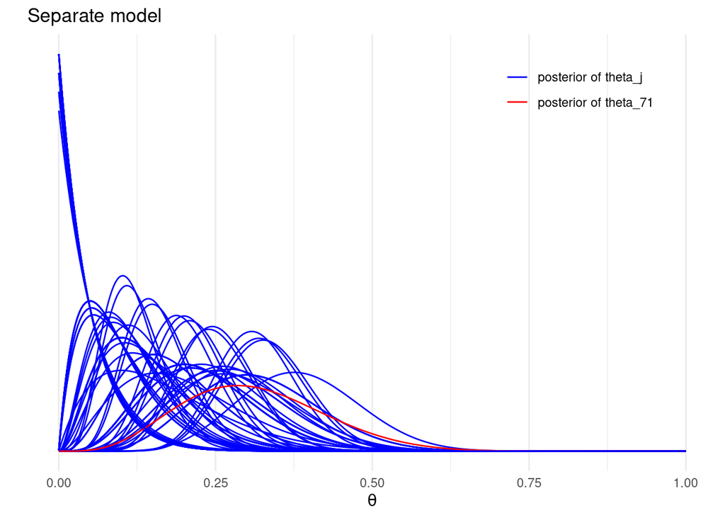

```r
labs1 <- paste('posterior of', c('theta_j', 'theta_71'))
plot_sep <- ggplot(data = df_sep) +
  geom_line(aes(x = x, y = p, color = (ind=='V71'), group = ind)) +
  labs(x = expression(theta), y = '', title = 'Separate model', color = '') +
  scale_y_continuous(breaks = NULL) +
  scale_color_manual(values = c('blue','red'), labels = labs1) +
  theme(legend.background = element_blank(), legend.position = c(0.8,0.9))
# The last one is for emphasize colored red
plot_sep
```

Pooled model

```r
df_pool <- data.frame(x = x, p = dbeta(x, sum(y)+1, sum(n)-sum(y)+1))
```

```r
plot_pool <- ggplot(data = df_pool) +
  geom_line(aes(x = x, y = p, color = '1')) +
  labs(x = expression(theta), y = '', title = 'Pooled model', color = '') +
  scale_y_continuous(breaks = NULL) +
  scale_color_manual(values = 'red', labels = 'Posterior of common theta') +
  theme(legend.background = element_blank(), legend.position = c(0.7,0.9))
```

Plot both separate and pooled model

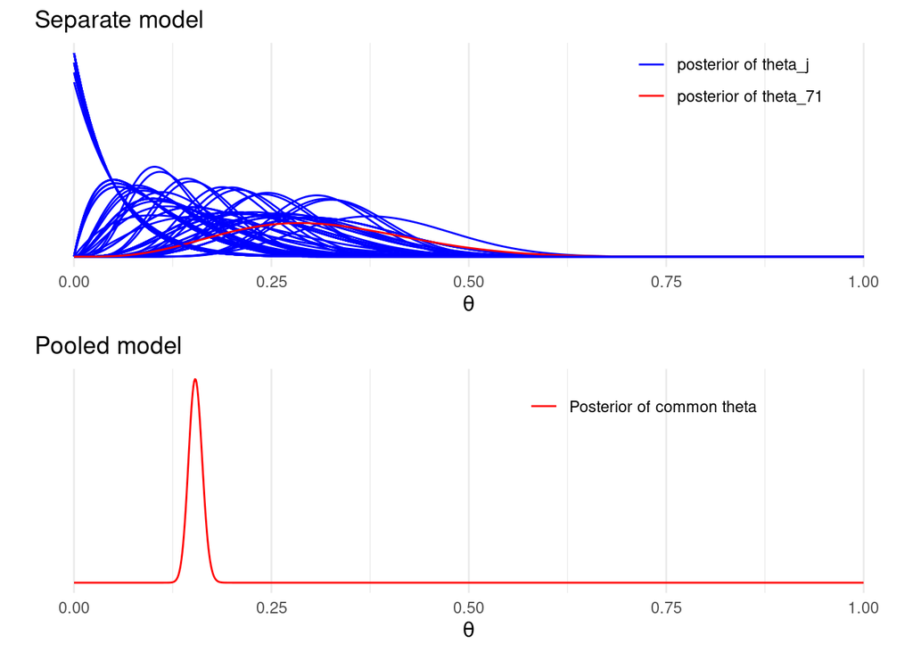

```r
grid.arrange(plot_sep, plot_pool)
```

Compute the marginal posterior of alpha and beta in hierarchical model Use grid

```r
A <- seq(0.5, 6, length.out = 100)
B <- seq(3, 33, length.out = 100)
```

Make vectors that contain all pairwise combinations of A and B

```r
cA <- rep(A, each = length(B))
cB <- rep(B, length(A))
```

Use logarithms for numerical accuracy!

```r
lpfun <- function(a, b, y, n) log(a+b)*(-5/2) +
  sum(lgamma(a+b)-lgamma(a)-lgamma(b)+lgamma(a+y)+lgamma(b+n-y)-lgamma(a+b+n))
lp <- mapply(lpfun, cA, cB, MoreArgs = list(y, n))
```

Subtract maximum value to avoid over/underflow in exponentation

```r
df_marg <- data.frame(x = cA, y = cB, p = exp(lp - max(lp)))
```

Create a plot of the marginal posterior density

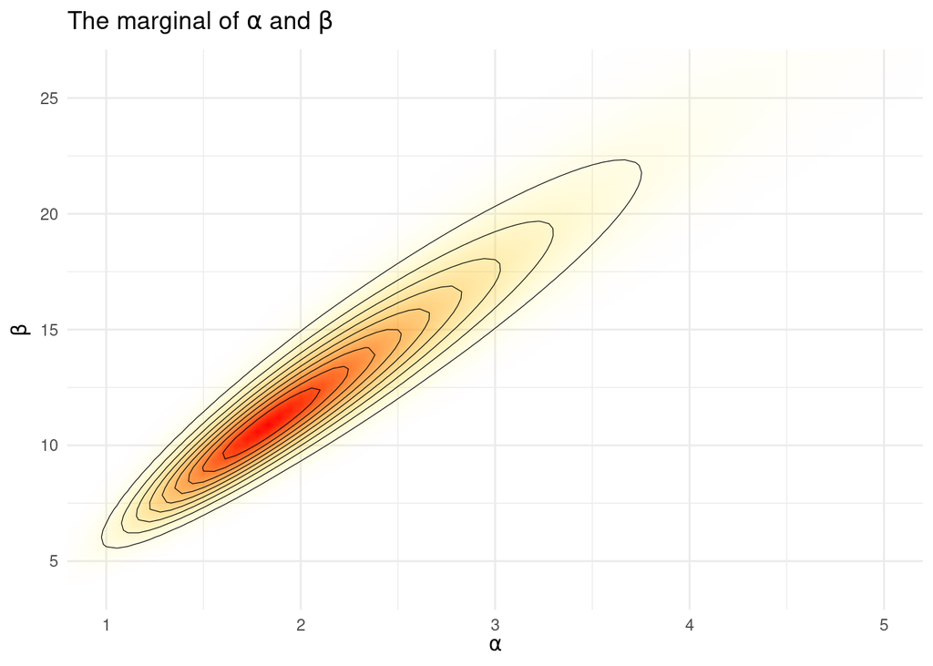

```r
title1 <- TeX('The marginal of $\\alpha$ and $\\beta$')
ggplot(data = df_marg, aes(x = x, y = y)) +
  geom_raster(aes(fill = p, alpha = p), interpolate = T) +
  geom_contour(aes(z = p), colour = 'black', size = 0.2) +
  coord_cartesian(xlim = c(1,5), ylim = c(4, 26)) +
  labs(x = TeX('$\\alpha$'), y = TeX('$\\beta$'), title = title1) +
  scale_fill_gradient(low = 'yellow', high = 'red', guide = F) +
  scale_alpha(range = c(0, 1), guide = F)
```

Sample from the grid (with replacement)

```r
nsamp <- 100
samp_indices <- sample(length(df_marg$p), size = nsamp,
                       replace = T, prob = df_marg$p/sum(df_marg$p))
samp_A <- cA[samp_indices[1:nsamp]]
samp_B <- cB[samp_indices[1:nsamp]]
df_psamp <- mapply(function(a, b, x) dbeta(x, a, b),
                  samp_A, samp_B, MoreArgs = list(x = x)) %>%
  as.data.frame() %>% cbind(x) %>%
  pivot_longer(cols = !x, names_to = "ind", values_to = "p")
```

Create plot for samples from the distribution of distributions Beta(alpha,beta), that is, plot Beta(alpha,beta) using posterior samples of alpha and beta

```r
# helper function to convert ind to numeric for subsetting
indtonum <- function(x) strtoi(substring(x,2))
title2 <- TeX('Beta($\\alpha,\\beta$) given posterior draws of $\\alpha$ and $\\beta$')
plot_psamp <- ggplot(data = subset(df_psamp, indtonum(ind) <= 20)) +
  geom_line(aes(x = x, y = p, group = ind), color='forestgreen') +
  labs(x = expression(theta), y = '', title = title2) +
  scale_y_continuous(breaks = NULL)
```

The average of above distributions, is the predictive distribution for a new theta, and also the prior distribution for theta_j

```r
df_psampmean <- spread(df_psamp, ind, p) %>% subset(select = -x) %>%
    rowMeans() %>% data.frame(x = x, p = .)
```

Create plot for samples from the predictive distribution for new theta

```r
title3 <- TeX('Population distribution (prior) for $\\theta_j$')
plot_psampmean <- ggplot(data = df_psampmean) +
  geom_line(aes(x = x, y = p), color='forestgreen') +
  labs(x = expression(theta), y = '', title = title3) +
  scale_y_continuous(breaks = NULL)
```

Combine the plots

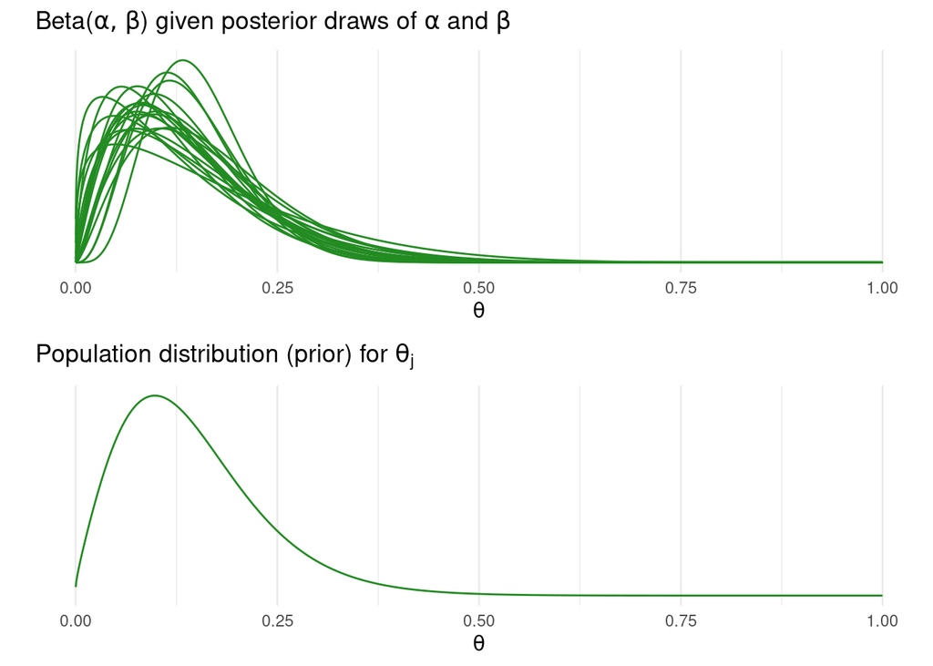

```r
grid.arrange(plot_psamp, plot_psampmean)
```

And finally compare the separate model and hierarchical model (using every seventh sample for clarity) Create plot for the separate model

```r
plot_sep7 <- ggplot(data = subset(df_sep, indtonum(ind)%%7==0)) +
  geom_line(aes(x = x, y = p, color = (ind=='V49'), group = ind)) +
  labs(x = expression(theta), y = '', title = 'Separate model', color = '') +
  scale_y_continuous(breaks = NULL) +
  scale_color_manual(values = c('blue', 'red'), guide = F) +
  theme(legend.background = element_blank(), legend.position = c(0.8,0.9))
```

The hierarchical model

Note that these marginal posteriors for theta_j are more narrow than in the separate model case, due to the borrowed information from the other theta_j’s

Average density over samples (of a and b) for each (n,y)-pair at each point x

```r
bdens2 <- function(n, y, a, b, x)
  rowMeans(mapply(dbeta, a + y, n - y + b, MoreArgs = list(x = x)))
df_hier <- mapply(bdens2, n, y, MoreArgs = list(samp_A, samp_B, x)) %>%
  as.data.frame() %>% cbind(x) %>%
  pivot_longer(cols = !x, names_to = "ind", values_to = "p")
```

Create plot for the hierarchical model

```r
plot_hier7 <- ggplot(data = subset(df_hier, indtonum(ind)%%7==0)) +
  geom_line(aes(x = x, y = p, color = (ind=='V49'), group = ind)) +
  labs(x = expression(theta), y = '', title = 'Hierarchical model', color = '') +
  scale_color_manual(values = c('blue', 'red'), guide = F) +
  scale_y_continuous(breaks = NULL) +
  theme(legend.background = element_blank(), legend.position = c(0.8,0.9))
```

Combine the plots

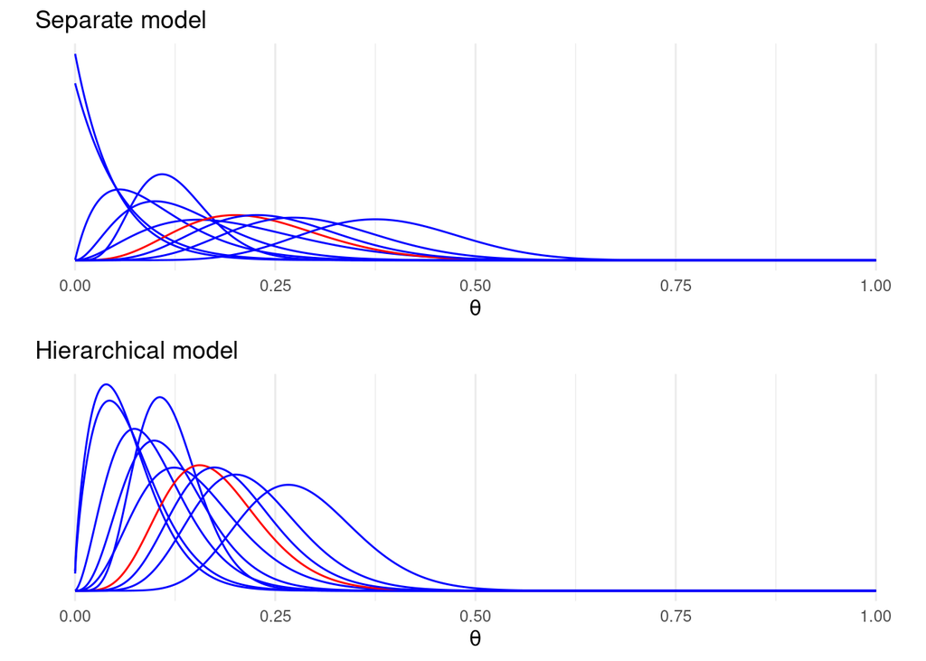

```r
grid.arrange(plot_sep7, plot_hier7)
```

```r
qq_separate<-data.frame(id=1:length(n), n=n, y=y,
               q10=qbeta(0.1,y+1,n-y+1), q50=qbeta(0.5,y+1,n-y+1), q90=qbeta(0.9,y+1,n-y+1))
```

```r
qh <- function(q, n, y) colMeans(mapply(function(q, n, y, a, b)
    mapply(qbeta, q, a + y, n - y + b), q, n, y, MoreArgs = list(samp_A, samp_B)))
qq_hier <- data.frame(id=1:length(n), n=n, y=y,
                      q10 = qh(0.1, n, y), q50 = qh(0.5, n, y), q90 = qh(0.9, n, y))
```

pooled mean

```r
m_pooled <- (sum(y)+1)/(sum(n)+2)
```

plot

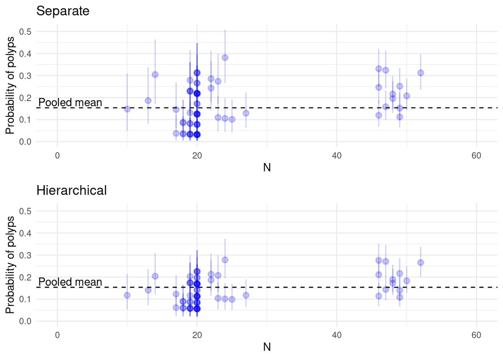

```r
plot_sep_int <- qq_separate %>%
  ggplot(aes(x=n,y=q50,ymin=q10,ymax=q90)) +
  geom_pointrange(color="blue", alpha=0.2) +
  geom_hline(yintercept=m_pooled, linetype="dashed")+
  lims(x=c(0,60), y=c(0,0.51))+
  labs(x="N", y="Probability of polyps", title="Separate")+
  annotate("text", x=0, y=m_pooled, label = "Pooled mean", vjust=-0.2, hjust=0.3)
plot_hier_int <- qq_hier %>%
  ggplot(aes(x=n,y=q50,ymin=q10,ymax=q90)) +
  geom_pointrange(color="blue", alpha=0.2) +
  geom_hline(yintercept=m_pooled, linetype="dashed")+
  lims(x=c(0,60), y=c(0,0.51))+
  labs(x="N", y="Probability of polyps", title="Hierarchical")+
  annotate("text", x=0, y=m_pooled, label = "Pooled mean", vjust=-0.2, hjust=0.3)
grid.arrange(plot_sep_int, plot_hier_int)
```